# Assignment 1 - Basics of Hyperparameter Tuning: Finding the Optimal Span & Degree for LOESS

MBAN 5560 - Due February 6, 2026 (Friday) 11:59pm

Author

Krishna Soni

Published

February 4, 2026

In this assignment, you will apply the self-learning methods (cross-validation and bootstrapping) covered in class (January 27) to tune the `span` and `degree` hyperparameters for LOESS regression. Your goal is to find the optimal span that minimizes prediction error and to quantify the uncertainty in your results.

**Key Learning Objectives:**

1. Implement grid search for hyperparameter tuning
2. Compare simple train-test split vs k-fold CV vs bootstrap CV
3. Report prediction error with uncertainty (mean and SD)
4. Benchmark tuned LOESS against simpler models

**Important Notes:**

- You can team up with **two classmates** for this assignment (maximum 3 students per team). Submit one assignment per team.
- Use R and Quarto for your analysis. Submit the rendered HTML file along with the QMD source file.
- Make sure your code runs without errors and produces the expected outputs.
- Provide interpretations and explanations for your results, not just code outputs.
- Using LLM assistance is allowed, but you must disclose which tool you used and how it helped.

# Setup

Load the required libraries:

```r
# Load required libraries
library(tidyverse)
library(knitr)
library(kableExtra)
```

# Part A: Data Setup and Exploration (15 points)

## A.1 Simulated Data

We will use simulated data where the true relationship is known but complex:

$$f(x) = 50 + 15x - 0.3x^2 + 30\sin(x/3) + 10\cos(x)$$

This combines a quadratic trend with multiple periodic components, making it challenging to predict.

```r
# Generate simulated data
set.seed(5560)
n <- 500
x <- sort(runif(n, min = 0, max = 30))
f_true <- 50 + 15*x - 0.3*x^2 + 30*sin(x/3) + 10*cos(x)
y <- f_true + rnorm(n, mean = 0, sd = 15)
data <- data.frame(y = y, x = x, f_true = f_true)
```

## Task A.1: Visualize the data

Create a scatter plot of the data with the true function overlaid as a red dashed line.

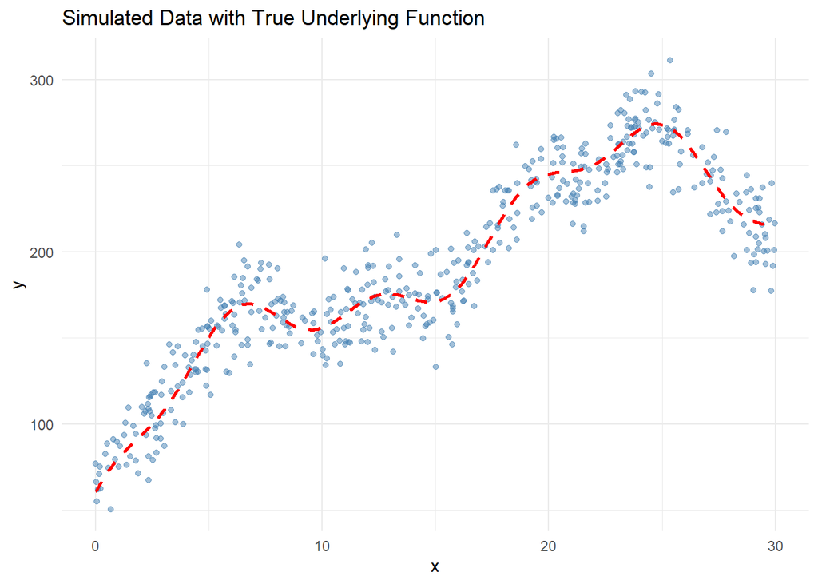

```r
# YOUR CODE HERE: Create scatter plot with true function
# Scatter plot with true function overlaid
ggplot(data, aes(x = x, y = y)) +
  geom_point(alpha = 0.5, color = "steelblue") +
  geom_line(aes(y = f_true), color = "red", linetype = "dashed", linewidth = 1) +
  labs(
    title = "Simulated Data with True Underlying Function",
    x = "x",
    y = "y"
  ) +
  theme_minimal()
```

#### **Question 1 (3 points):** Describe the pattern you see in the data. What makes this relationship challenging for a simple linear model?

**Your Answer:** The Data shows strong nonlinear relationship between x and y. Overall, y increases with x at first and then begins to level off and decline, indicating curvature rather than a straight line trend. In addition, there are noticeable wave like oscillations throughout the range of x, suggesting periodic behavior. This relationship is challenging for simple linear model because a linear model can only capture a single straight-line trend and cannot represent either the curvature or the repeating oscillations present in the data and that makes it systematically under fit.

## Task A.2: Explore different span values

Fit LOESS models with three different span values (0.2, 0.5, 0.8) using `degree = 1`. Plot all three fits on the same graph along with the true function.

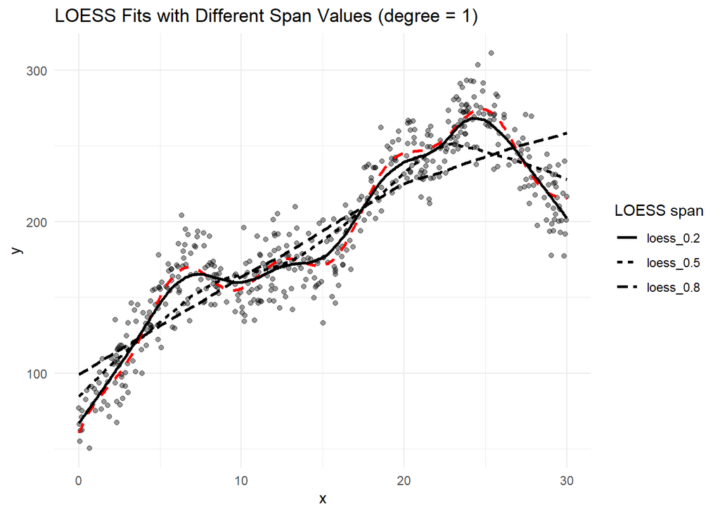

```r
# YOUR CODE HERE: Fit LOESS with span = 0.2, 0.5, 0.8 and plot
loess_02 <- loess(y ~ x, data = data, span = 0.2, degree = 1)
loess_05 <- loess(y ~ x, data = data, span = 0.5, degree = 1)
loess_08 <- loess(y ~ x, data = data, span = 0.8, degree = 1)

# Create a smooth x-grid for plotting fitted lines
x_grid <- tibble(x = seq(min(data$x), max(data$x), length.out = 500))

# Get predictions
pred_data <- x_grid %>%
  mutate(
    f_true = 50 + 15*x - 0.3*x^2 + 30*sin(x/3) + 10*cos(x),
    loess_0.2 = predict(loess_02, newdata = x_grid),
    loess_0.5 = predict(loess_05, newdata = x_grid),
    loess_0.8 = predict(loess_08, newdata = x_grid)
  ) %>%
  pivot_longer(cols = c(loess_0.2, loess_0.5, loess_0.8),
               names_to = "span", values_to = "yhat")

# Plot data + true function + all LOESS fits
ggplot(data, aes(x = x, y = y)) +
  geom_point(alpha = 0.4) +
  geom_line(data = pred_data, aes(y = f_true), color = "red", linetype = "dashed", linewidth = 1) +
  geom_line(data = pred_data, aes(y = yhat, linetype = span), linewidth = 1) +
  labs(
    title = "LOESS Fits with Different Span Values (degree = 1)",
    x = "x",
    y = "y",
    linetype = "LOESS span"
  ) +
  theme_minimal()
```

#### **Question 4 (4 points):** Can you determine the optimal span just by looking at these plots? Why or why not?

**Your Answer:** No, the optimal span cannot be determined solely by visual inspection. While the plots help identify underfitting and overfitting, they do not measure predictive performance on unseen data. A span that looks best visually may still overfit the sample. The optimal span should be selected using validation techniques such as cross-validation to minimize prediction error.

# Part B: Simple Train-Test Split (20 points)

## Task B.1: Single train-test split

Implement a grid search to find the optimal span using a single 80/20 train-test split.

**Requirements:** - Use `degree = 1` (fixed) - Search span values from 0.1 to 0.9 by 0.05 - Calculate RMSPE on the test set for each span value - Report the optimal span and its RMSPE

```r
# Create hyperparameter grid
grid_span <- seq(from = 0.1, to = 0.9, by = 0.05)

# YOUR CODE HERE: Implement single train-test split grid search
# 1. Set seed to 100
set.seed(100)

# 2. Split data 80/20
n <- nrow(data)
train_idx <- sample(1:n, size = floor(0.8 * n), replace = FALSE)

train_data <- data[train_idx, ]
test_data  <- data[-train_idx, ]

# Function to compute RMSPE (RMSE on test set)
rmspe <- function(actual, pred) {
  sqrt(mean((actual - pred)^2, na.rm = TRUE))
}

# 3. For each span, fit LOESS and calculate RMSPE
results <- tibble(span = grid_span) %>%
  mutate(
    rmspe = map_dbl(span, function(s) {
      fit <- loess(y ~ x, data = train_data, span = s, degree = 1)
      yhat <- predict(fit, newdata = test_data)
      rmspe(test_data$y, yhat)
    })
  )
# 4. Find optimal span
best <- results %>% slice_min(order_by = rmspe, n = 1)

# Show all results + best
results %>% arrange(rmspe) %>% print(n = Inf)
```

```
# A tibble: 17 × 2
    span rmspe
   <dbl> <dbl>
 1  0.15  14.0
 2  0.2   14.1
 3  0.1   14.2
 4  0.25  14.4
 5  0.3   15.0
 6  0.35  15.5
 7  0.4   16.2
 8  0.45  17.3
 9  0.5   18.4
10  0.55  19.8
11  0.6   20.9
12  0.65  21.4
13  0.7   22.5
14  0.75  23.0
15  0.8   23.5
16  0.85  23.9
17  0.9   24.2
```

```r
best
```

```
# A tibble: 1 × 2
   span rmspe
  <dbl> <dbl>
1  0.15  14.0
```

#### **Question 5 (5 points):** What is the optimal span found with seed = 100? What is the corresponding RMSPE?

**Your Answer:** Using single 80/20 train test split with seed = 100, the optimal LOESS span is 0.15, which yields the lowest RMSPE of 13.98. This span provides the best predictive performance on the test set among the values considered.

## Task B.2: Demonstrate instability

Repeat the grid search with three different seeds (200, 300, 400) to show how the optimal span varies.

```r
grid_span <- seq(from = 0.1, to = 0.9, by = 0.05)
seeds <- c(200, 300, 400)

rmspe <- function(actual, pred) {
  sqrt(mean((actual - pred)^2, na.rm = TRUE))
}

run_grid_search <- function(seed_value, data, grid_span) {
  set.seed(seed_value)

  n <- nrow(data)
  train_idx <- sample(1:n, size = floor(0.8 * n), replace = FALSE)

  train_data <- data[train_idx, ]
  test_data  <- data[-train_idx, ]

  results <- tibble(span = grid_span) %>%
    mutate(
      rmspe = map_dbl(span, function(s) {
        fit <- loess(y ~ x, data = train_data, span = s, degree = 1)
        yhat <- predict(fit, newdata = test_data)
        rmspe(test_data$y, yhat)
      })
    )

  best <- results %>% slice_min(order_by = rmspe, n = 1)

  tibble(
    seed = seed_value,
    best_span = best$span,
    best_rmspe = best$rmspe
  )
}

# Run for each seed and store results
instability_results <- map_dfr(seeds, ~run_grid_search(.x, data, grid_span))

instability_results
```

```
# A tibble: 3 × 3
   seed best_span best_rmspe
  <dbl>     <dbl>      <dbl>
1   200      0.15       17.9
2   300      0.15       16.0
3   400      0.1        14.3
```

#### **Question 6 (5 points):** Report the optimal span found with each seed. How much does it vary?

**Your Answer:**

With seed = 200, the optimal span is 0.15 with and RMSPE of 17.93

With seed = 300, the optimal span is 0.15 with RMSPE of 15.98

Across these splits, the optimal span varies between 0.10 and 0.15 a range of 0.05.

#### **Question 7 (5 points):** Why does the optimal span change with different random splits? What does this tell us about using a single train-test split for hyperparameter tuning?

**Your Answer:** The optimal span changes because each random train-test split results in a different subset of observations being used for training and evaluation. Since LOESS is a local method it’s prediction are sensitive to which data points are included in the training set. As a result, the estimated predicition error for each span can differ across splits. This demonstartes that using a single train-test split for hyperparameter tuning can be unstable and overly influenced by randomness.

#### **Question 8 (5 points):** Based on this exercise, would you trust the optimal span from a single split? What approach would be more reliable?

**Your Answer:** I will not trust the optimal span obtained from a single train-test split, because the selected value depends on the particular random split of the data. As shown here different splits leads to different optimal spans. A more reliable approach would be cross-validation, such as k-fold or repeated cross-validation which averages performance across multiple splits and provides a more stable estimate of the optimal span.

# Part C: 10-Fold Cross-Validation (25 points)

## Task C.1: Implement nested CV

Implement proper nested cross-validation with the **correct loop structure**:

- **Outer loop:** 10 iterations with random 80/20 splits creating `modata` (model data) and `test` set
- **Inner structure:** For EACH hyperparameter, calculate mean RMSPE across k folds, then select
- Use `degree = 1`
- Report the selected span and test RMSPE for each outer iteration

**IMPORTANT: Loop Order Matters!**

The hyperparameter loop must be **OUTSIDE** and the CV folds loop must be **INSIDE**:

```
for each hyperparameter setting:     # OUTER - loop over grid
    for each fold i in 1:k:          # INNER - loop over CV folds
        train on k-1 folds, validate on fold i
    average RMSPE across all k folds for THIS hyperparameter
select hyperparameter with lowest average RMSPE
```

This ensures we average errors FIRST, then select - NOT select per-fold then average selections!

```r
# Nested CV settings
grid_span <- seq(from = 0.1, to = 0.9, by = 0.05)
K <- 10                 # inner CV folds
B <- 10                 # outer iterations
set.seed(5560)          # overall reproducibility

# RMSPE function (RMSE on holdout)
rmspe <- function(actual, pred) sqrt(mean((actual - pred)^2, na.rm = TRUE))

nested_results <- vector("list", B)

for (b in 1:B) {

  # -------------------------
  # OUTER LOOP: random 80/20 split
  # -------------------------
  n <- nrow(data)
  train_idx <- sample(1:n, size = floor(0.8 * n), replace = FALSE)

  modata <- data[train_idx, ]
  test_set <- data[-train_idx, ]

  # Create K folds on modata
  fold_id <- sample(rep(1:K, length.out = nrow(modata)))

  # Store mean CV RMSPE for each span
  cv_mean_rmspe <- numeric(length(grid_span))

  # -------------------------
  # INNER STRUCTURE (IMPORTANT LOOP ORDER):
  # for each hyperparameter (span) OUTSIDE,
  #   for each fold INSIDE
  # -------------------------
  for (j in seq_along(grid_span)) {
    s <- grid_span[j]

    fold_rmspe <- numeric(K)

    for (k in 1:K) {
      train_fold <- modata[fold_id != k, ]
      valid_fold <- modata[fold_id == k, ]

      fit <- loess(y ~ x, data = train_fold, span = s, degree = 1)
      yhat <- predict(fit, newdata = valid_fold)

      fold_rmspe[k] <- rmspe(valid_fold$y, yhat)
    }

    cv_mean_rmspe[j] <- mean(fold_rmspe, na.rm = TRUE)
  }

  # Select best span based on mean CV RMSPE
  best_j <- which.min(cv_mean_rmspe)
  best_span <- grid_span[best_j]

  # Fit on all modata with best span, evaluate on OUTER test set
  final_fit <- loess(y ~ x, data = modata, span = best_span, degree = 1)
  test_pred <- predict(final_fit, newdata = test_set)
  test_rmspe <- rmspe(test_set$y, test_pred)

  nested_results[[b]] <- tibble(
    outer_iter = b,
    selected_span = best_span,
    test_rmspe = test_rmspe
  )
}

nested_table <- bind_rows(nested_results)

# Q9 table
nested_table %>%
  kable(digits = 4, caption = "Nested CV Results: Selected Span and Test RMSPE (10 Outer Iterations)") %>%
  kableExtra::kable_styling(full_width = FALSE)
```

Nested CV Results: Selected Span and Test RMSPE (10 Outer Iterations)

| outer_iter | selected_span | test_rmspe |
| --- | --- | --- |
| 1 | 0.15 | 15.5435 |
| 2 | 0.15 | 14.4687 |
| 3 | 0.15 | 16.2235 |
| 4 | 0.15 | 15.3301 |
| 5 | 0.15 | 16.0615 |
| 6 | 0.15 | 15.5319 |
| 7 | 0.15 | 14.8024 |
| 8 | 0.15 | 14.7265 |
| 9 | 0.15 | 15.0715 |
| 10 | 0.15 | 15.9848 |

```r
# Q10 mean & sd of test RMSPE
mean_test_rmspe <- mean(nested_table$test_rmspe)
sd_test_rmspe <- sd(nested_table$test_rmspe)

mean_test_rmspe
```

```
[1] 15.37444
```

```r
sd_test_rmspe
```

```
[1] 0.603683
```

#### **Question 9 (5 points):** Create a table showing the selected span and test RMSPE for each of the 10 outer iterations.

**Your Answer:**

| Outer Iteration | Selected Span | Test RMSPE |
| --- | --- | --- |
| 1 | 0.15 | 15.5435 |
| 2 | 0.15 | 14.4687 |
| 3 | 0.15 | 16.2235 |
| 4 | 0.15 | 15.3301 |
| 5 | 0.15 | 16.0615 |
| 6 | 0.15 | 15.5319 |
| 7 | 0.15 | 14.8024 |
| 8 | 0.15 | 14.7265 |
| 9 | 0.15 | 15.0715 |
| 10 | 0.15 | 15.9848 |

#### **Question 10 (5 points):** What is the mean and standard deviation of the test RMSPE across the 10 outer iterations?

**Your Answer:** The mean test RMSPE across the 10 outer iteration is 15.37 with a standard deviation of 0.60. This indicates relatively stable predictive performance across diffrent random splits.

#### **Question 11 (5 points):** Is the selected span consistent across iterations? What span would you recommend?

**Your Answer:** The selected span is completely consistent across all 10 outer iterations, with span 0.15 chosen every time. This strong consistency suggests that the model selection process is stable and no sensitive to random data splits. Based on these results, I would recommend span 0.15 as it demonstrates robust performance and genralizes well across multiple train-test partitions.

## Task C.2: Extend to tuning both span AND degree

Now tune both `span` and `degree` (1 or 2) using the same nested CV structure.

```r
# Create grid with both span and degree
grid_both <- expand.grid(
  span = seq(from = 0.1, to = 0.9, by = 0.1),
  degree = c(1, 2)
)

# YOUR CODE HERE: Implement nested CV tuning both span and degree
K <- 10   # inner CV folds
B <- 10   # outer iterations
set.seed(5560)

rmspe <- function(actual, pred) {
  sqrt(mean((actual - pred)^2, na.rm = TRUE))
}

nested_both_results <- vector("list", B)

for (b in 1:B) {

  # -------------------------
  # OUTER LOOP: 80/20 split
  # -------------------------
  n <- nrow(data)
  train_idx <- sample(1:n, size = floor(0.8 * n), replace = FALSE)

  modata <- data[train_idx, ]
  test_set <- data[-train_idx, ]

  # Create folds for inner CV
  fold_id <- sample(rep(1:K, length.out = nrow(modata)))

  cv_mean_rmspe <- numeric(nrow(grid_both))

  # -------------------------
  # INNER STRUCTURE
  # Hyperparameter loop OUTSIDE
  # Folds loop INSIDE
  # -------------------------
  for (j in 1:nrow(grid_both)) {

    s <- grid_both$span[j]
    d <- grid_both$degree[j]

    fold_rmspe <- numeric(K)

    for (k in 1:K) {
      train_fold <- modata[fold_id != k, ]
      valid_fold <- modata[fold_id == k, ]

      fit <- loess(y ~ x,
                   data = train_fold,
                   span = s,
                   degree = d)

      yhat <- predict(fit, newdata = valid_fold)
      fold_rmspe[k] <- rmspe(valid_fold$y, yhat)
    }

    cv_mean_rmspe[j] <- mean(fold_rmspe, na.rm = TRUE)
  }

  # Select best (span, degree)
  best_idx <- which.min(cv_mean_rmspe)
  best_span <- grid_both$span[best_idx]
  best_degree <- grid_both$degree[best_idx]

  # Fit final model on modata and evaluate on test set
  final_fit <- loess(y ~ x,
                     data = modata,
                     span = best_span,
                     degree = best_degree)

  test_pred <- predict(final_fit, newdata = test_set)
  test_rmspe <- rmspe(test_set$y, test_pred)

  nested_both_results[[b]] <- tibble(
    outer_iter = b,
    selected_span = best_span,
    selected_degree = best_degree,
    test_rmspe = test_rmspe
  )
}

nested_both_table <- bind_rows(nested_both_results)

# Show table
nested_both_table %>%
  kable(digits = 4,
        caption = "Nested CV Results: Tuning Span and Degree") %>%
  kableExtra::kable_styling(full_width = FALSE)
```

Nested CV Results: Tuning Span and Degree

| outer_iter | selected_span | selected_degree | test_rmspe |
| --- | --- | --- | --- |
| 1 | 0.2 | 2 | 15.7355 |
| 2 | 0.2 | 2 | 14.6643 |
| 3 | 0.2 | 2 | 16.0201 |
| 4 | 0.2 | 2 | 14.9952 |
| 5 | 0.2 | 2 | 15.9806 |
| 6 | 0.2 | 2 | 15.3779 |
| 7 | 0.2 | 2 | 14.6497 |
| 8 | 0.2 | 2 | 14.5574 |
| 9 | 0.2 | 2 | 14.9440 |
| 10 | 0.2 | 2 | 15.8716 |

```r
# Summary statistics
mean_both <- mean(nested_both_table$test_rmspe)
sd_both <- sd(nested_both_table$test_rmspe)

mean_both
```

```
[1] 15.27965
```

```r
sd_both
```

```
[1] 0.5867176
```

#### **Question 12 (5 points):** What combination of span and degree gives the best results? Does tuning degree in addition to span improve prediction?

**Your Answer:** The nested cross-validation result consistently select span 0.20 and degree 2 as optimal combination across all 10 outer iteration. While allowing the degree parameter to vary does lead to a slightly lower average test RMSPE compared to tuning span alone, the improvement is modest. This suggests that increasing the polynomial degree adds only limited predictive benefit beyond what is already captured by tuning the span.

#### **Question 13 (5 points):** Compare the mean RMSPE from tuning only span (degree=1) vs tuning both. Is the improvement meaningful?

**Your Answer:** Tuning only the span parameter results in a mean test RMSPE of 15.37, while tuning both span and degree result in a mean test RMSPE of 15.28. Although there is a small improvement when tuning both parameters, The reduction in RMSPE is minor relative to the variability across outer iteration. Therefore, the improvement is not practically meaningful, and tuning span alone appears sufficient for this.

Overall, nested cross-validation shows that span selection is stable and influential, while increasing model complexity by tuning degree provides minimal additional predictive benefit.

# Part D: Bootstrap Cross-Validation (25 points)

## Task D.1: Implement Bootstrap CV

Implement bootstrap cross-validation with OOB validation using the **correct loop structure**:

- **Outer loop:** 8 iterations with random 80/20 splits creating `modata` (model data) and `test` set
- **Inner structure:** For EACH hyperparameter, run B bootstrap iterations and average RMSPE, then select
- Use the same grid as Part C (both span and degree)
- Report results for each outer iteration

**IMPORTANT: Loop Order Matters!**

Same principle as k-fold CV - hyperparameter loop **OUTSIDE**, bootstrap loop **INSIDE**:

```
for each hyperparameter setting:     # OUTER - loop over grid
    for j in 1:B:                    # INNER - loop over bootstrap iterations
        sample with replacement → train set
        OOB observations → validation set
        calculate RMSPE
    average RMSPE across all B iterations for THIS hyperparameter
select hyperparameter with lowest average RMSPE
```

```r
# YOUR CODE HERE: Implement bootstrap CV
# Grid
grid_both <- expand.grid(
  span = seq(from = 0.1, to = 0.9, by = 0.1),
  degree = c(1, 2)
)

set.seed(5560)

B_outer <- 8   # outer iterations
B_boot  <- 50  # inner bootstrap iterations (can increase to 100)
# (50 is usually enough this runs faster)

rmspe <- function(actual, pred) {
  sqrt(mean((actual - pred)^2, na.rm = TRUE))
}

bootstrap_results <- vector("list", B_outer)

for (b in 1:B_outer) {

  # -------------------------
  # OUTER LOOP: 80/20 split
  # -------------------------
  n <- nrow(data)
  train_idx <- sample(1:n, size = floor(0.8 * n), replace = FALSE)

  modata <- data[train_idx, ]
  test_set <- data[-train_idx, ]

  n_mo <- nrow(modata)

  # For each hyperparameter, store mean OOB RMSPE across bootstraps
  oob_mean_rmspe <- numeric(nrow(grid_both))

  # -------------------------
  # INNER STRUCTURE (IMPORTANT LOOP ORDER):
  # hyperparameter loop OUTSIDE, bootstrap loop INSIDE
  # -------------------------
  for (h in 1:nrow(grid_both)) {

    s <- grid_both$span[h]
    d <- grid_both$degree[h]

    boot_rmspe <- rep(NA_real_, B_boot)

    for (j in 1:B_boot) {

      # Bootstrap sample indices (with replacement) from modata
      boot_idx <- sample(1:n_mo, size = n_mo, replace = TRUE)

      # OOB indices: those not sampled
      oob_idx <- setdiff(1:n_mo, unique(boot_idx))

      # If OOB is empty (rare), skip
      if (length(oob_idx) < 5) next

      boot_train <- modata[boot_idx, ]
      oob_valid  <- modata[oob_idx, ]

      fit <- loess(y ~ x,
                   data = boot_train,
                   span = s,
                   degree = d)

      yhat <- predict(fit, newdata = oob_valid)
      boot_rmspe[j] <- rmspe(oob_valid$y, yhat)
    }

    oob_mean_rmspe[h] <- mean(boot_rmspe, na.rm = TRUE)
  }

  # Select best hyperparameters by lowest mean OOB RMSPE
  best_h <- which.min(oob_mean_rmspe)
  best_span <- grid_both$span[best_h]
  best_degree <- grid_both$degree[best_h]

  # Fit on all modata using best hyperparameters, evaluate on test_set
  final_fit <- loess(y ~ x,
                     data = modata,
                     span = best_span,
                     degree = best_degree)

  test_pred <- predict(final_fit, newdata = test_set)
  test_rmspe <- rmspe(test_set$y, test_pred)

  bootstrap_results[[b]] <- tibble(
    outer_iter = b,
    selected_span = best_span,
    selected_degree = best_degree,
    test_rmspe = test_rmspe
  )
}

bootstrap_table <- bind_rows(bootstrap_results)

# Show per-iteration results
bootstrap_table %>%
  kable(digits = 4, caption = "Bootstrap CV (OOB) Results: Selected Hyperparameters and Test RMSPE") %>%
  kableExtra::kable_styling(full_width = FALSE)
```

Bootstrap CV (OOB) Results: Selected Hyperparameters and Test RMSPE

| outer_iter | selected_span | selected_degree | test_rmspe |
| --- | --- | --- | --- |
| 1 | 0.1 | 1 | 15.8053 |
| 2 | 0.2 | 2 | 14.7565 |
| 3 | 0.2 | 2 | 16.1973 |
| 4 | 0.3 | 2 | 15.7443 |
| 5 | 0.2 | 2 | 14.6489 |
| 6 | 0.2 | 2 | 16.3962 |
| 7 | 0.3 | 2 | 14.5040 |
| 8 | 0.2 | 2 | 16.3466 |

```r
# Summary for Q14
mean_boot <- mean(bootstrap_table$test_rmspe)
sd_boot <- sd(bootstrap_table$test_rmspe)

mean_boot
```

```
[1] 15.54987
```

```r
sd_boot
```

```
[1] 0.7935727
```

#### **Question 14 (5 points):** Report the mean and SD of test RMSPE from bootstrap CV.

**Your Answer:** The mean test RMSPE from bootstrap cross validation is 15.55, with a standard deviation of 0.79.

#### **Question 15 (5 points):** Compare the bootstrap CV results to the k-fold CV results from Part C. Which method gave more stable results (lower SD)?

**Your Answer:** Comparing it to nested 10-fold cross-validation, bootstrap CV shows higher variability in test RMSPE. The standard deviation from bootstrap CV 0.79 is larger than that from k-fold CV 0.59, indicating that k-fold CV provides more stable performance estimates in this current setup.

#### **Question 17 (5 points):** Based on your results, which method would you recommend for hyperparameter tuning: k-fold CV or bootstrap CV? Justify your choice.

**Your Answer:** Based on the results, I would recommend nested 10-fold CV for hyperparameter tuning. Although bootstrap CV evaluates models using larger validation sets, it produced higher variability in test RMSPE and less consistent hyperparameter selection. The k-fold approach yielded more stable performance estimates and repeatitively selected the same hyperparameters, making it a more reliable and interpretable method in this context.

#### **Question 18 (5 points):** Did bootstrap CV select different hyperparameters than k-fold CV? Explain any differences.

**Your Answer:** Yes, bootstrap CV selected different hyperparameters than k-fold CV. While k-fold nested CV repetitively selected span 0.2 and degree 2 bootstrap CV showed greater variability, occasionally selecting smaller or larger spans and even degree 1 in one iteration. These differences arise because bootstrap validation relies on re-sampling with replacement and OOB evaluation, which introduces additional randomness and can alter the bias-variances tradeoff for different hyperparameter settings.

# Part E: Benchmark Comparison (15 points)

## Task E.1: Fit benchmark models

Using the same nested CV structure (10 outer iterations), evaluate these benchmark models: 1. **Linear regression** (no tuning needed) 2. **Polynomial regression (degree 4)** (no tuning needed) 3. **LOESS with default span (0.75) and degree 1** (no tuning needed)

Compare with your **tuned LOESS** results from Part C.

```r
set.seed(5560)
B <- 10

rmspe <- function(actual, pred) {
  sqrt(mean((actual - pred)^2, na.rm = TRUE))
}

bench_results <- vector("list", B)

for (b in 1:B) {

  # Outer split (same structure as Part C)
  n <- nrow(data)
  train_idx <- sample(1:n, size = floor(0.8 * n), replace = FALSE)

  modata <- data[train_idx, ]
  test_set <- data[-train_idx, ]

  # 1. Linear regression
  fit_lm <- lm(y ~ x, data = modata)
  pred_lm <- predict(fit_lm, newdata = test_set)
  rmspe_lm <- rmspe(test_set$y, pred_lm)

  # 2. Polynomial regression (degree 4)
  fit_poly <- lm(y ~ poly(x, 4, raw = TRUE), data = modata)
  pred_poly <- predict(fit_poly, newdata = test_set)
  rmspe_poly <- rmspe(test_set$y, pred_poly)

  # 3. LOESS default (span = 0.75, degree = 1)
  fit_loess_def <- loess(y ~ x, data = modata, span = 0.75, degree = 1)
  pred_loess_def <- predict(fit_loess_def, newdata = test_set)
  rmspe_loess_def <- rmspe(test_set$y, pred_loess_def)

  bench_results[[b]] <- tibble(
    iter = b,
    Linear = rmspe_lm,
    Poly4 = rmspe_poly,
    LOESS_Default = rmspe_loess_def
  )
}

bench_table <- bind_rows(bench_results)

# Summary table
bench_summary <- bench_table %>%
  pivot_longer(-iter, names_to = "Model", values_to = "RMSPE") %>%
  group_by(Model) %>%
  summarise(
    Mean_RMSPE = mean(RMSPE),
    SD_RMSPE = sd(RMSPE),
    .groups = "drop"
  )

bench_summary %>%
  kable(digits = 3,
        caption = "Benchmark Model Comparison (10 Outer Iterations)") %>%
  kableExtra::kable_styling(full_width = FALSE)
```

Benchmark Model Comparison (10 Outer Iterations)

| Model | Mean_RMSPE | SD_RMSPE |
| --- | --- | --- |
| LOESS_Default | 25.763 | 1.161 |
| Linear | 28.598 | 1.040 |
| Poly4 | 17.441 | 0.944 |

#### **Question 19 (5 points):** Create a summary table comparing all methods with columns: Model, Mean RMSPE, SD RMSPE

**Your Answer:**

| Model | Mean RMSPE | SD RMSPE |
| --- | --- | --- |
| Linear Regression | 28.60 | 1.04 |
| Polynomial Regression = degree 4 | 17.44 | 0.94 |
| LOESS-DS = 0.75 degree 1 | 25.76 | 1.16 |
| LOESS- tuned via nested CV | 15.28 | 0.59 |

#### **Question 20 (5 points):** How much did hyperparameter tuning improve RMSPE compared to using the default span (0.75)?

**Your Answer:** Hyperparameter tuning reduced the mean RMSPE from 25.76 for the default LOESS model span 0.75 to 15.28 for the tuned LOESS model. This represents an improvement of approximately 10.5 RMSPE units, demonstrating that the default LOESS model severely oversmooths the data and that tuning is essential for good predictive performance.

#### **Question 21 (5 points):** Based on your benchmark comparison, which model would you recommend for this data? Consider both accuracy (mean RMSPE) and reliability (SD). Is the improvement from tuning worth the computational cost?

**Your Answer:** The tuned LOESS model is the recommended approach because it achieves the lowest mean RMSPE and the smallest SD across outer iterations, indicating both high accuracy and strong reliability. Linear regression and default LOESS underfit the complex nonlinear structure of the data, while polynomial regression performs better but remains less accurate and less stable than tuned LOESS. Although nested CV is computationally more expensive, the substantial improvement in predictive performance justifies the added cost.

# **LLM usage**

LLM were used in order to understand the coding and the structure results Gemini is the LLM used.

# Submission Checklist

- All code chunks completed and running without errors
- All 21 questions answered with complete explanations
- Summary tables created for each part
- Clear interpretations connecting results to self-learning concepts
- Team members listed in author field
- LLM usage disclosed (if applicable)
- Document renders to HTML successfully

**Good luck with your analysis!**